# Check formula of crossproduct of a random vector

Andrey Ziyatdinov

2018-04-09

# 1 Parameters

```r
S <- 500 # the number of simulations
N <- as.integer(c(100, 200, 500)) # the number of individuals
p <- 0.3 # the MAF of SNPs
f <- 0.4 # the frequency of binary exposure
```

# 2 Genetic variable

## 2.1 Genetic variable in unrelated: centered

```r
out <- lapply(N, function(n) {
  par <- gxefam_par(num_fam = n / 5, sim_gen = "rbinom", sim_phen = "no_rand",
    freq_g  = p)

  prod <- sapply(seq(1, S), function(s) {
    xg <- gxefam_sim_gen(par)
    xg_c <- xg - mean(xg)

    as.numeric(crossprod(xg_c))
  })

  data_frame(N = as.integer(n), prod = prod)
})

tab <- bind_rows(out)

tab_expected <- data_frame(N = N) %>%
  mutate(
    prod = 2 * p * (1 - p) * N)
```

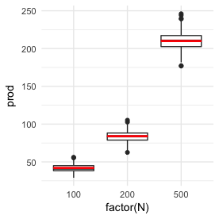

## 2.2 Genetic variable in unrelated: not centered

```r
out <- lapply(N, function(n) {
  par <- gxefam_par(num_fam = n / 5, sim_gen = "rbinom", sim_phen = "no_rand",
    freq_g  = p)

  prod <- sapply(seq(1, S), function(s) {
    xg <- gxefam_sim_gen(par)

    as.numeric(crossprod(xg))
  })

  data_frame(N = as.integer(n), prod = prod)
})

tab <- bind_rows(out)

tab_expected <- data_frame(N = N) %>%
  mutate(
    prod = 2 * p * (1 - p) * N + (2 * p)^2 * N)
```

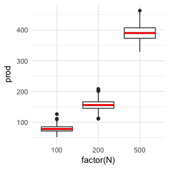

## 2.3 Genetic variable in related: centered

$E(x_c^T x_c) = tr(V)$

- $V = \sigma^2_x K$
- $\sigma^2_x = 2 p q$
- $tr(K) = N$ (all diagonal entries of $K$ are 1)

```r
out <- lapply(N, function(n) {
  par <- gxefam_par(num_fam = n / 5, sim_gen = "rbinom_fam", sim_phen = "no_rand",
    freq_g  = p)

  prod <- sapply(seq(1, S), function(s) {
    xg <- gxefam_sim_gen(par)
    xg_c <- xg - mean(xg)

    as.numeric(crossprod(xg_c))
  })

  data_frame(N = as.integer(n), prod = prod)
})

tab <- bind_rows(out)

tab_expected <- data_frame(N = N) %>%
  mutate(
    prod = 2 * p * (1 - p) * N)
```

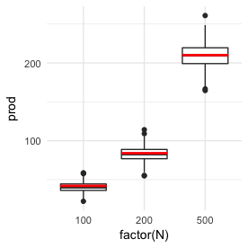

## 2.4 Genetic variable in related: not centered

$E(x_c^T x_c) = tr(V) + \mu^T \mu$

The first term:

- $V = \sigma^2_x K$
- $\sigma^2_x = 2 p q$
- $tr(K) = N$ (all diagonal entries of $K$ are 1)

The second term:

```r
out <- lapply(N, function(n) {
  par <- gxefam_par(num_fam = n / 5, sim_gen = "rbinom_fam", sim_phen = "no_rand",
    freq_g  = p)

  prod <- sapply(seq(1, S), function(s) {
    xg <- gxefam_sim_gen(par)

    as.numeric(crossprod(xg))
  })

  data_frame(N = as.integer(n), prod = prod)
})

tab <- bind_rows(out)

tab_expected <- data_frame(N = N) %>%
  mutate(
    prod = 2 * p * (1 - p) * N + (2 * p)^2 * N)
```

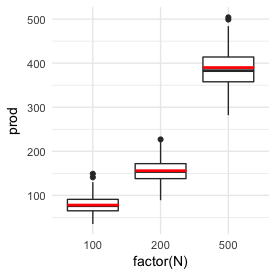

# 3 Stratified genetic variable

## 3.1 Genetic variable in unrelated: centered; stratified

$x_c \sim (0, V) = (0, \sigma_x^2 I)$

$y = A x_c \sim (0, A^T V A)$

Then:

$y = diag(a) x_c = A x_c \sim (0, A^T V A) = (0, \sigma_x^2 A^T A) = (0, \sigma_x^2 diag(a^2))$

Since elements in $a$ are 0 and 1:

$y \sim (0, \sigma_x^2 diag(a)) = (0, V_y)$

Further:

$E(y^T y) = tr(V_y) = f \sigma_x^2 N = 2 p q f N$

```r
out <- lapply(N, function(n) {
  par <- gxefam_par(num_fam = n / 5, sim_gen = "rbinom", sim_phen = "no_rand",
    freq_g  = p)

  prod <- sapply(seq(1, S), function(s) {
    xg <- gxefam_sim_gen(par)
    xg_c <- xg - mean(xg)

    xs <- c(rep(1, f * n), rep(0, (1 - f) * n))
    xgs <- as.numeric(diag(xs) %*% xg_c)

    as.numeric(crossprod(xgs))
  })

  data_frame(N = as.integer(n), prod = prod)
})

tab <- bind_rows(out)

tab_expected <- data_frame(N = N) %>%
  mutate(
    prod = 2 * p * (1 - p) * f * N)
```

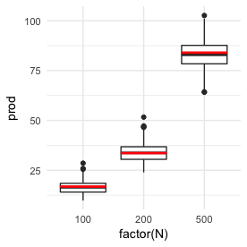

## 3.2 Genetic variable in unrelated: centered; stratified by centered

$x_c \sim (0, V) = (0, \sigma_x^2 I)$

$y = A x_c \sim (0, A^T V A)$

Then:

$y = a_c x_c = diag(a - \mu_a) x_c = A_c x_c \sim (0, A_c^T V A_c) = (0, \sigma_x^2 A_c^T A_c) = (0, \sigma_x^2 diag((a - \mu_a)^2)) = (0, \sigma_x^2 diag(a_c^2))$

Further:

$a_c^2 = (a - \mu_a)^2 = a^2 - 2 \mu_a a + \mu_a^2 = a - 2 \mu_a a + \mu_a^2 = (1 - 2 \mu_a) a + \mu_a^2$

Next:

$E(y^T y) = tr(V_y) = \sigma_x^2 \mu_{a_c^2} N = 2 p q f (1 - f) N$

```r
out <- lapply(N, function(n) {
  par <- gxefam_par(num_fam = n / 5, sim_gen = "rbinom", sim_phen = "no_rand",
    freq_g  = p)

  prod <- sapply(seq(1, S), function(s) {
    xg <- gxefam_sim_gen(par)
    xg_c <- xg - mean(xg)

    xs <- c(rep(1, f * n), rep(0, (1 - f) * n))
    xs_c <- xs - mean(xs)

    xgs <- as.numeric(diag(xs_c) %*% xg_c)

    as.numeric(crossprod(xgs))
  })

  data_frame(N = as.integer(n), prod = prod)
})

tab <- bind_rows(out)

tab_expected <- data_frame(N = N) %>%
  mutate(
    prod = 2 * p * (1 - p) * f * (1 - f)* N)
```

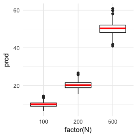

## 3.3 Genetic variable in related: centered; stratified by centered

$x_c \sim (0, V) = (0, \sigma_x^2 I)$

$y = A x_c \sim (0, A^T V A)$

Then:

$y = a_c x_c = diag(a - \mu_a) x_c = A_c x_c \sim (0, A_c^T V A_c)$

Further:

$V = [V_{11}, V_{22}, V_{12}, V_{21}]$

Next:

$E(y^T y) = tr(V_y) = \sigma_x^2 \mu_{a_c^2} N = 2 p q f (1 - f) N$

```r
out <- lapply(N, function(n) {
  par <- gxefam_par(num_fam = n / 5, sim_gen = "rbinom_fam", sim_phen = "no_rand",
    freq_g  = p)

  prod <- sapply(seq(1, S), function(s) {
    xg <- gxefam_sim_gen(par)
    xg_c <- xg - mean(xg)

    xs <- c(rep(1, f * n), rep(0, (1 - f) * n))
    xs_c <- xs - mean(xs)

    xgs <- as.numeric(diag(xs_c) %*% xg_c)

    as.numeric(crossprod(xgs))
  })

  data_frame(N = as.integer(n), prod = prod)
})

tab <- bind_rows(out)

tab_expected <- data_frame(N = N) %>%
  mutate(
    prod = 2 * p * (1 - p) * f * (1 - f)* N)
```

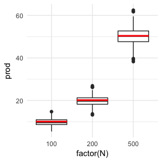

## 3.4 Genetic variable in related: centered; stratified by affected-siblings & centered

$E(y^T y) = tr(V_y) = \sigma_x^2 \mu_{a_c^2} N = 2 p q f (1 - f) N$

```r
out <- lapply(N, function(n) {
  par <- gxefam_par(num_fam = n / 5, sim_gen = "rbinom_fam", sim_phen = "no_rand",
    sim_env = "exposed_sib",
    freq_g  = p)

  prod <- sapply(seq(1, S), function(s) {
    xg <- gxefam_sim_gen(par)
    xg_c <- xg - mean(xg)

    xs <- gxefam_sim_env(par)
    xs_c <- xs - mean(xs)

    xgs <- as.numeric(diag(xs_c) %*% xg_c)

    as.numeric(crossprod(xgs))
  })

  data_frame(N = as.integer(n), prod = prod)
})

tab <- bind_rows(out)

tab_expected <- data_frame(N = N) %>%
  mutate(
    f_sib = 3 / 5,
    prod = 2 * p * (1 - p) * f_sib * (1 - f_sib)* N)
```

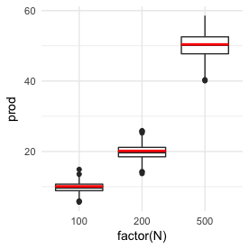

$E(y^T y) = tr(V_y) = \sigma_x^2 \mu_{a_c^2} N = 2 p q f (1 - f) N$

```r
out <- lapply(N, function(n) {
  par <- gxefam_par(num_fam = n / 5, sim_gen = "rbinom_fam", sim_phen = "no_rand",
    sim_env = "exposed_sib",
    freq_g  = p)

  prod <- sapply(seq(1, S), function(s) {
    xg <- gxefam_sim_gen(par)
    xg_c <- xg - mean(xg)

    xs <- gxefam_sim_env(par)
    xs_c <- xs - mean(xs)

    xgs <- as.numeric(diag(xs_c) %*% xg_c)

    as.numeric(crossprod(xgs))
  })

  data_frame(N = as.integer(n), prod = prod)
})

tab <- bind_rows(out)

tab_expected <- data_frame(N = N) %>%
  mutate(
    prod = 2 * p * (1 - p) * f * (1 - f)* N)
```

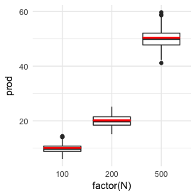

# 4 Varicance-covariance matrix of the interaction variable

```r
par <- gxefam_par(num_fam = 2, sim_gen = "rbinom_fam", sim_env = "exposed_sib",
  sim_phen = "no_rand", freq_g = p)
st <- gxefam_famstruct(par)

K <- st$mat_gen

xs <- gxefam_sim_env(par)
xsc <- xs - mean(xs)

A <- diag(xs)
Ac <- diag(xsc)

V <- Matrix(A %*% K %*% A)
Vc <- Matrix(Ac %*% K %*% Ac)
```

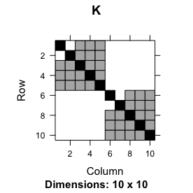

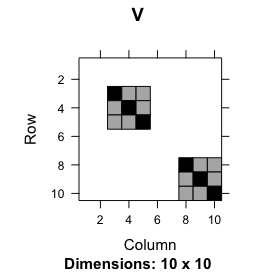

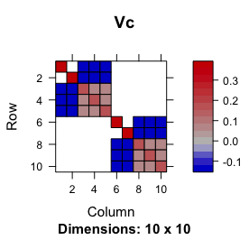

```r
K
```

```
10 x 10 sparse Matrix of class "dgTMatrix"

1001 1.0 .   0.5 0.5 0.5 .   .   .   .   .
1002 .   1.0 0.5 0.5 0.5 .   .   .   .   .
1003 0.5 0.5 1.0 0.5 0.5 .   .   .   .   .
1004 0.5 0.5 0.5 1.0 0.5 .   .   .   .   .
1005 0.5 0.5 0.5 0.5 1.0 .   .   .   .   .
2001 .   .   .   .   .   1.0 .   0.5 0.5 0.5
2002 .   .   .   .   .   .   1.0 0.5 0.5 0.5
2003 .   .   .   .   .   0.5 0.5 1.0 0.5 0.5
2004 .   .   .   .   .   0.5 0.5 0.5 1.0 0.5
2005 .   .   .   .   .   0.5 0.5 0.5 0.5 1.0
```

```r
V
```

```
10 x 10 sparse Matrix of class "dsCMatrix"

 [1,] . . .   .   .   . . .   .   .
 [2,] . . .   .   .   . . .   .   .
 [3,] . . 1.0 0.5 0.5 . . .   .   .
 [4,] . . 0.5 1.0 0.5 . . .   .   .
 [5,] . . 0.5 0.5 1.0 . . .   .   .
 [6,] . . .   .   .   . . .   .   .
 [7,] . . .   .   .   . . .   .   .
 [8,] . . .   .   .   . . 1.0 0.5 0.5
 [9,] . . .   .   .   . . 0.5 1.0 0.5
[10,] . . .   .   .   . . 0.5 0.5 1.0
```

```r
Vc
```

```
10 x 10 sparse Matrix of class "dsCMatrix"

 [1,]  0.36  .    -0.12 -0.12 -0.12  .     .     .     .     .
 [2,]  .     0.36 -0.12 -0.12 -0.12  .     .     .     .     .
 [3,] -0.12 -0.12  0.16  0.08  0.08  .     .     .     .     .
 [4,] -0.12 -0.12  0.08  0.16  0.08  .     .     .     .     .
 [5,] -0.12 -0.12  0.08  0.08  0.16  .     .     .     .     .
 [6,]  .     .     .     .     .     0.36  .    -0.12 -0.12 -0.12
 [7,]  .     .     .     .     .     .     0.36 -0.12 -0.12 -0.12
 [8,]  .     .     .     .     .    -0.12 -0.12  0.16  0.08  0.08
 [9,]  .     .     .     .     .    -0.12 -0.12  0.08  0.16  0.08
[10,]  .     .     .     .     .    -0.12 -0.12  0.08  0.08  0.16
```

## 4.1 Multiply by inverse K

```r
Kinv <- solve(K)

W <- Matrix(Kinv %*% A %*% K %*% A)
Wc <- Matrix(Kinv %*% Ac %*% K %*% Ac)
```

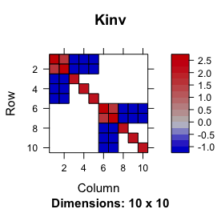

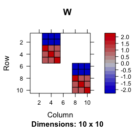

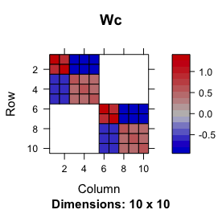